# BMI 713/BMIF 313qc Class 7: Data Visualization / 25 September 2018

Nils Gehlenborg

## NEISS Data

NEISS Data can be downloaded from the NEISS Query Builder. Data files have to be downloaded by year:

https://www.cpsc.gov/cgibin/NEISSQuery/home.aspx: Check “Researcher” box for the first question, then download data files and code book as tab-delimited text files.

An R package of the NEISS data is available as well:

https://github.com/hadley/neiss

Here’s an interactive example visualization of NEISS data:

https://flowingdata.com/2016/02/09/why-people-visit-the-emergency-room/

### Loading the Data

We will use `read_tsv()` from the `readr` package to load the file.

```r
# potential issue in line 160879: additional line break?
neiss <- read_tsv("data/neiss2017.tsv")
```

Let’s have a quick look at the tibble to see what we parsed.

```r
# column types and preview of values
str(neiss)
```

```
## Classes 'tbl_df', 'tbl' and 'data.frame':    386906 obs. of  19 variables:
##  $ CPSC_Case_Number: int  170100733 170100734 170100735 170100737 170100740 170102019 170102021 170102025 170102026 170102907 ...
##  $ Treatment_Date  : chr  "01/01/2017" "01/01/2017" "01/01/2017" "01/01/2017" ...
##  $ Age             : int  21 71 16 55 86 58 21 54 21 35 ...
##  $ Sex             : int  1 1 1 2 2 1 1 1 1 2 ...
##  $ Race            : int  1 1 1 1 1 1 1 1 1 0 ...
##  $ Other_Race      : chr  NA NA NA NA ...
##  $ Body_Part       : int  75 31 33 75 79 31 79 75 82 79 ...
##  $ Diagnosis       : int  62 53 51 62 58 53 64 62 57 64 ...
##  $ Other_Diagnosis : chr  NA NA NA NA ...
##  $ Disposition     : int  1 1 1 1 1 1 1 2 1 1 ...
##  $ Location        : int  1 5 1 1 1 1 1 5 1 1 ...
##  $ Fire_Involvement: int  0 0 0 0 0 0 0 0 0 0 ...
##  $ Product_1       : int  1207 1807 676 620 1646 649 4076 1807 1884 1807 ...
##  $ Product_2       : int  0 0 342 0 4056 1807 0 0 0 0 ...
##  $ Narrative_1     : chr  "21YOM WAS BOXING WITH FRIEND WHILE DRINKING AND GOT PUNCHED IN THE FACE" "71YOM FELL ON FLOOR IN BATHROOM. DX RIB CONTUSION" "16YOM TRIPPED OVER A RUG AND FELL INTO A BURNING FIREPLACE" "55YOF WAS STANDING ON A STEP STOOL AND LOST FOOTING AND FELL. DX CLOSED" ...
##  $ Narrative_2     : chr  ". BAC= 93.6 DX HEAD INJURY AND ALCOHOL INTOXICATION" NA "DX BURNS INVOLVING LESS THAN 10% OF BODY SURFACE, FOREARM" "HEAD INJURY" ...
##  $ Stratum         : chr  "S" "S" "S" "S" ...
##  $ PSU             : int  46 46 46 46 46 72 72 72 72 14 ...
##  $ Weight          : num  77.7 77.7 77.7 77.7 77.7 ...
##  - attr(*, "spec")=List of 2
##   ..$ cols   :List of 19
##   .. ..$ CPSC_Case_Number: list()
##   .. .. ..- attr(*, "class")= chr  "collector_integer" "collector"
##   .. ..$ Treatment_Date  : list()
##   .. .. ..- attr(*, "class")= chr  "collector_character" "collector"
##   .. ..$ Age             : list()
##   .. .. ..- attr(*, "class")= chr  "collector_integer" "collector"
##   .. ..$ Sex             : list()
##   .. .. ..- attr(*, "class")= chr  "collector_integer" "collector"
##   .. ..$ Race            : list()
##   .. .. ..- attr(*, "class")= chr  "collector_integer" "collector"
##   .. ..$ Other_Race      : list()
##   .. .. ..- attr(*, "class")= chr  "collector_character" "collector"
##   .. ..$ Body_Part       : list()
##   .. .. ..- attr(*, "class")= chr  "collector_integer" "collector"
##   .. ..$ Diagnosis       : list()
##   .. .. ..- attr(*, "class")= chr  "collector_integer" "collector"
##   .. ..$ Other_Diagnosis : list()
##   .. .. ..- attr(*, "class")= chr  "collector_character" "collector"
```

[output cut: 8 more lines]

```
##   .. ..$ Product_2       : list()
##   .. .. ..- attr(*, "class")= chr  "collector_integer" "collector"
##   .. ..$ Narrative_1     : list()
##   .. .. ..- attr(*, "class")= chr  "collector_character" "collector"
##   .. ..$ Narrative_2     : list()
##   .. .. ..- attr(*, "class")= chr  "collector_character" "collector"
##   .. ..$ Stratum         : list()
##   .. .. ..- attr(*, "class")= chr  "collector_character" "collector"
##   .. ..$ PSU             : list()
##   .. .. ..- attr(*, "class")= chr  "collector_integer" "collector"
##   .. ..$ Weight          : list()
##   .. .. ..- attr(*, "class")= chr  "collector_double" "collector"
##   ..$ default: list()
##   .. ..- attr(*, "class")= chr  "collector_guess" "collector"
##   ..- attr(*, "class")= chr "col_spec"
```

We can also get a summary of some key statistics.

```r
summary(neiss)
```

```
##  CPSC_Case_Number    Treatment_Date          Age              Sex
##  Min.   :170100733   Length:386906      Min.   :  0.00   Min.   :0.000
##  1st Qu.:170443976   Class :character   1st Qu.: 12.00   1st Qu.:1.000
##  Median :170736136   Mode  :character   Median : 29.00   Median :1.000
##  Mean   :171028151                      Mean   : 44.37   Mean   :1.461
##  3rd Qu.:171025483                      3rd Qu.: 60.00   3rd Qu.:2.000
##  Max.   :180319227                      Max.   :223.00   Max.   :2.000
##       Race         Other_Race          Body_Part       Diagnosis
##  Min.   :0.0000   Length:386906      Min.   : 0.00   Min.   :41.00
##  1st Qu.:0.0000   Class :character   1st Qu.:35.00   1st Qu.:57.00
##  Median :1.0000   Mode  :character   Median :75.00   Median :59.00
##  Mean   :0.9354                      Mean   :64.41   Mean   :60.59
##  3rd Qu.:1.0000                      3rd Qu.:82.00   3rd Qu.:64.00
##  Max.   :6.0000                      Max.   :94.00   Max.   :74.00
##  Other_Diagnosis     Disposition       Location     Fire_Involvement
##  Length:386906      Min.   :1.000   Min.   :0.000   Min.   :0.000000
##  Class :character   1st Qu.:1.000   1st Qu.:0.000   1st Qu.:0.000000
##  Mode  :character   Median :1.000   Median :1.000   Median :0.000000
##                     Mean   :1.345   Mean   :2.488   Mean   :0.008987
##                     3rd Qu.:1.000   3rd Qu.:5.000   3rd Qu.:0.000000
##                     Max.   :9.000   Max.   :9.000   Max.   :3.000000
##    Product_1      Product_2      Narrative_1        Narrative_2
##  Min.   : 102   Min.   :   0.0   Length:386906      Length:386906
##  1st Qu.:1205   1st Qu.:   0.0   Class :character   Class :character
##  Median :1807   Median :   0.0   Mode  :character   Mode  :character
##  Mean   :2104   Mean   : 283.5
##  3rd Qu.:3265   3rd Qu.:   0.0
##  Max.   :5555   Max.   :5555.0
##    Stratum               PSU             Weight
##  Length:386906      Min.   :  1.00   Min.   : 4.757
##  Class :character   1st Qu.: 21.00   1st Qu.:15.447
##  Mode  :character   Median : 38.00   Median :16.992
##                     Mean   : 44.71   Mean   :38.065
##                     3rd Qu.: 67.00   3rd Qu.:75.565
##                     Max.   :101.00   Max.   :87.090
```

It turns out that the treatment dates were parsed as character strings. In order to be able to work with dates (e.g. to summarize or group data by month or day), we need to tell the parser that we want to read the `Treatment_Date` column as dates.

```r
neiss <- read_tsv("data/neiss2017.tsv", col_types = cols(Treatment_Date = col_date(format="%m/%d/%Y")))
```

```r
str(neiss)
```

```
## Classes 'tbl_df', 'tbl' and 'data.frame':    386906 obs. of  19 variables:
##  $ CPSC_Case_Number: int  170100733 170100734 170100735 170100737 170100740 170102019 170102021 170102025 170102026 170102907 ...
##  $ Treatment_Date  : Date, format: "2017-01-01" "2017-01-01" ...
##  $ Age             : int  21 71 16 55 86 58 21 54 21 35 ...
##  $ Sex             : int  1 1 1 2 2 1 1 1 1 2 ...
##  $ Race            : int  1 1 1 1 1 1 1 1 1 0 ...
##  $ Other_Race      : chr  NA NA NA NA ...
##  $ Body_Part       : int  75 31 33 75 79 31 79 75 82 79 ...
##  $ Diagnosis       : int  62 53 51 62 58 53 64 62 57 64 ...
##  $ Other_Diagnosis : chr  NA NA NA NA ...
##  $ Disposition     : int  1 1 1 1 1 1 1 2 1 1 ...
##  $ Location        : int  1 5 1 1 1 1 1 5 1 1 ...
##  $ Fire_Involvement: int  0 0 0 0 0 0 0 0 0 0 ...
##  $ Product_1       : int  1207 1807 676 620 1646 649 4076 1807 1884 1807 ...
##  $ Product_2       : int  0 0 342 0 4056 1807 0 0 0 0 ...
##  $ Narrative_1     : chr  "21YOM WAS BOXING WITH FRIEND WHILE DRINKING AND GOT PUNCHED IN THE FACE" "71YOM FELL ON FLOOR IN BATHROOM. DX RIB CONTUSION" "16YOM TRIPPED OVER A RUG AND FELL INTO A BURNING FIREPLACE" "55YOF WAS STANDING ON A STEP STOOL AND LOST FOOTING AND FELL. DX CLOSED" ...
##  $ Narrative_2     : chr  ". BAC= 93.6 DX HEAD INJURY AND ALCOHOL INTOXICATION" NA "DX BURNS INVOLVING LESS THAN 10% OF BODY SURFACE, FOREARM" "HEAD INJURY" ...
##  $ Stratum         : chr  "S" "S" "S" "S" ...
##  $ PSU             : int  46 46 46 46 46 72 72 72 72 14 ...
##  $ Weight          : num  77.7 77.7 77.7 77.7 77.7 ...
##  - attr(*, "spec")=List of 2
##   ..$ cols   :List of 19
##   .. ..$ CPSC_Case_Number: list()
##   .. .. ..- attr(*, "class")= chr  "collector_integer" "collector"
##   .. ..$ Treatment_Date  :List of 1
##   .. .. ..$ format: chr "%m/%d/%Y"
##   .. .. ..- attr(*, "class")= chr  "collector_date" "collector"
##   .. ..$ Age             : list()
##   .. .. ..- attr(*, "class")= chr  "collector_integer" "collector"
##   .. ..$ Sex             : list()
##   .. .. ..- attr(*, "class")= chr  "collector_integer" "collector"
##   .. ..$ Race            : list()
##   .. .. ..- attr(*, "class")= chr  "collector_integer" "collector"
##   .. ..$ Other_Race      : list()
##   .. .. ..- attr(*, "class")= chr  "collector_character" "collector"
##   .. ..$ Body_Part       : list()
##   .. .. ..- attr(*, "class")= chr  "collector_integer" "collector"
##   .. ..$ Diagnosis       : list()
##   .. .. ..- attr(*, "class")= chr  "collector_integer" "collector"
##   .. ..$ Other_Diagnosis : list()
```

[output cut: 9 more lines]

```
##   .. ..$ Product_2       : list()
##   .. .. ..- attr(*, "class")= chr  "collector_integer" "collector"
##   .. ..$ Narrative_1     : list()
##   .. .. ..- attr(*, "class")= chr  "collector_character" "collector"
##   .. ..$ Narrative_2     : list()
##   .. .. ..- attr(*, "class")= chr  "collector_character" "collector"
##   .. ..$ Stratum         : list()
##   .. .. ..- attr(*, "class")= chr  "collector_character" "collector"
##   .. ..$ PSU             : list()
##   .. .. ..- attr(*, "class")= chr  "collector_integer" "collector"
##   .. ..$ Weight          : list()
##   .. .. ..- attr(*, "class")= chr  "collector_double" "collector"
##   ..$ default: list()
##   .. ..- attr(*, "class")= chr  "collector_guess" "collector"
##   ..- attr(*, "class")= chr "col_spec"
```

## Count Cases per Month

```r
# https://ro-che.info/articles/2017-02-22-group_by_month_r
cases_month <- neiss %>% group_by(month=floor_date(Treatment_Date, "month"))

cases_month <- neiss %>% group_by(month=floor_date(Treatment_Date, "month")) %>% summarize(cases=n())

cases_month
```

```
## # A tibble: 12 x 2
##    month      cases
##    <date>     <int>
##  1 2017-01-01 28917
##  2 2017-02-01 26314
##  3 2017-03-01 30658
##  4 2017-04-01 33551
##  5 2017-05-01 36224
##  6 2017-06-01 34404
##  7 2017-07-01 34657
##  8 2017-08-01 34320
##  9 2017-09-01 36110
## 10 2017-10-01 34457
## 11 2017-11-01 29448
## 12 2017-12-01 27846
```

```r
stopifnot( sum(cases_month$cases) == dim(neiss)[1] )
```

## Count Cases per Weekday

```r
cases_weekday <- neiss %>% group_by(day = weekdays(Treatment_Date)) %>% summarize(cases = n())

cases_weekday
```

```
## # A tibble: 7 x 2
##   day       cases
##   <chr>     <int>
## 1 Friday    52332
## 2 Monday    57151
## 3 Saturday  57069
## 4 Sunday    58671
## 5 Thursday  53274
## 6 Tuesday   54154
## 7 Wednesday 54255
```

```r
stopifnot( sum(cases_weekday$cases) == dim(neiss)[1] )
```

## Add Additional Columns to Dataset

Because weekday and month might be handy when visualizing the data, we will add two columns to the tibble: `Treatment_Month` and `Treatment_Weekday`.

```r
# https://www.packtpub.com/mapt/book/big_data_and_business_intelligence/9781784390815/4/ch04lvl1sec52/adding-new-columns-with-dplyr
neiss <- neiss %>% mutate( Treatment_Weekday=factor(weekdays(Treatment_Date),
        levels=c("Sunday", "Monday", "Tuesday", "Wednesday", "Thursday", "Friday", "Saturday"))) %>% mutate( Treatment_Month = factor(months(Treatment_Date),
        levels=c("January", "February", "March", "April", "May", "June", "July", "August", "September", "October", "November", "December")))
```

## We Need a Mapping for the Codes

Many of the columnn in the tibble use codes that are impossible to interpret without looking them up. NEISS provides a mapping table that we will load now.

```r
neiss_codes <- read_tsv("data/neiss_fmt.txt")
```

The `Format name` column indicates the column name in the `neiss` tibble, the `Starting/Ending value for format` entries are the codes, and the `Format value label` are the human readable names for the codes. It seems that in most if not all rows the values for `Starting` and `Ending` values are the same. Let’s make sure our assumption about the starting and ending values being identical holds.

```r
#stopifnot( neiss_codes[,2] == neiss_codes[,3]  )
which(neiss_codes[,2] != neiss_codes[,3])
```

```
## [1] 2
```

The second row contains the codes for mapping ages > 2. That’s why an actual range is provided. All other rows are just using a single code and not a range.

```r
cat("AGELTTWO   2   120 2 YEARS AND OLDER")
```

```
## AGELTTWO 2   120 2 YEARS AND OLDER
```

Since we are not specifically interested in children under two, we will ignore that column for now.

## Mapping Variables using `match`

We will now map the codes for a couple of columns to the `neiss` tibble to get data that doesn’t require a lookup table. Let’s start with the `Body Part` column. First, we filter the tibble for rows containing codes related to body parts.

```r
# first we filter the body part rows from the code table
body_part_codes <- neiss_codes %>% filter(`Format name`=="BDYPT")
body_part_codes
```

```
## # A tibble: 30 x 4
##    `Format name` `Starting value for… `Ending value for… `Format value la…
##    <chr>                        <int>              <int> <chr>
##  1 BDYPT                            0                  0 0 - INTERNAL
##  2 BDYPT                           30                 30 30 - SHOULDER
##  3 BDYPT                           31                 31 31 - UPPER TRUNK
##  4 BDYPT                           32                 32 32 - ELBOW
##  5 BDYPT                           33                 33 33 - LOWER ARM
##  6 BDYPT                           34                 34 34 - WRIST
##  7 BDYPT                           35                 35 35 - KNEE
##  8 BDYPT                           36                 36 36 - LOWER LEG
##  9 BDYPT                           37                 37 37 - ANKLE
## 10 BDYPT                           38                 38 38 - PUBIC REGION
## # ... with 20 more rows
```

Next, we remove columns that we won’t need.

```r
body_part_codes <- body_part_codes %>% select(`Starting value for format`,`Format value label`)
body_part_codes
```

```
## # A tibble: 30 x 2
##    `Starting value for format` `Format value label`
##                          <int> <chr>
##  1                           0 0 - INTERNAL
##  2                          30 30 - SHOULDER
##  3                          31 31 - UPPER TRUNK
##  4                          32 32 - ELBOW
##  5                          33 33 - LOWER ARM
##  6                          34 34 - WRIST
##  7                          35 35 - KNEE
##  8                          36 36 - LOWER LEG
##  9                          37 37 - ANKLE
## 10                          38 38 - PUBIC REGION
## # ... with 20 more rows
```

Then, we rename columns to make it possible to use their names without backquotes.

```r
body_part_codes <- body_part_codes %>% rename(Code=`Starting value for format`)  %>% rename(Label=`Format value label`)
body_part_codes
```

```
## # A tibble: 30 x 2
##     Code Label
##    <int> <chr>
##  1     0 0 - INTERNAL
##  2    30 30 - SHOULDER
##  3    31 31 - UPPER TRUNK
##  4    32 32 - ELBOW
##  5    33 33 - LOWER ARM
##  6    34 34 - WRIST
##  7    35 35 - KNEE
##  8    36 36 - LOWER LEG
##  9    37 37 - ANKLE
## 10    38 38 - PUBIC REGION
## # ... with 20 more rows
```

Finally, we convert the `Label` column in to a factor.

```r
body_part_codes <- body_part_codes %>% mutate(Label=factor(Label))
body_part_codes
```

```
## # A tibble: 30 x 2
##     Code Label
##    <int> <fct>
##  1     0 0 - INTERNAL
##  2    30 30 - SHOULDER
##  3    31 31 - UPPER TRUNK
##  4    32 32 - ELBOW
##  5    33 33 - LOWER ARM
##  6    34 34 - WRIST
##  7    35 35 - KNEE
##  8    36 36 - LOWER LEG
##  9    37 37 - ANKLE
## 10    38 38 - PUBIC REGION
## # ... with 20 more rows
```

Using this clean code table and the `match` function, we will create a new column in the `neiss` tibble.

```r
body_part_code_mapping <- match(neiss$Body_Part, body_part_codes$Code)
neiss <- neiss %>% mutate(Body_Part_Label=body_part_codes[body_part_code_mapping,]$Label)
```

Since the label still includes the code value, we will redo this step and trim the code numbers using the `sub`(stitute) command.

```r
body_part_code_mapping <- match(neiss$Body_Part, body_part_codes$Code)
neiss <- neiss %>% mutate(Body_Part_Label=sub(".* - ", "", factor(body_part_codes[body_part_code_mapping,]$Label)))

# see ?regex for examples of patterns
# Note that we have to explicitly tell R that we want a factor !
```

Let’s repeat this for products and gender (leaving out a few steps that were included for illustration above).

```r
codes <- neiss_codes %>% filter(`Format name`=="PROD")
codes <- codes %>% rename(Code=`Starting value for format`)  %>% rename(Label=`Format value label`)
code_mapping <- match(neiss$Product_1, codes$Code)
neiss <- neiss %>% mutate(Product_1_Label=sub(".* - ", "", factor(codes[code_mapping,]$Label)))
code_mapping <- match(neiss$Product_2, codes$Code)
neiss <- neiss %>% mutate(Product_2_Label=sub(".* - ", "", factor(codes[code_mapping,]$Label)))

codes <- neiss_codes %>% filter(`Format name`=="GENDER")
codes <- codes %>% rename(Code=`Starting value for format`) %>% rename(Label=`Format value label`)
code_mapping <- match(neiss$Sex, codes$Code)
neiss <- neiss %>% mutate(Sex_Label=sub(".* - ", "", factor(codes[code_mapping,]$Label)))
```

Because it would be painful to repeat these steps manually for every variable that we want to map, we will create a function that will do that for us. The only parameters that we need in addition to the data and code tibbles are the name of the code table column, the name of the `neiss` column, and the name of the new column to be added to the `neiss` tibble.

```r
map_codes <- function( data_tibble, code_tibble, data_column_name, new_data_column_name, code_column_key ) {
  # data_column_name = variable name (e.g. "Body_Part")
  # new_data_column_name = variable name (e.g. "Body_Part_Label")
  # code_column_key = code table first column value (e.g. "BDYPT")

  # ... This will be on your homework assignment

  return( data_tibble )
}

# map_codes( neiss, neiss_codes, "Location", "Location_Label", "LOC" )
```

## Save the Tibble for Future Use

Since we don’t want to re-run the data cleaning steps every time we want to work with our NEISS data tibble, we will store it in a file that we can easily reload.

```r
save(neiss, neiss_codes,file="data/neiss.Rdata")
```

## Let’s Make a Plot

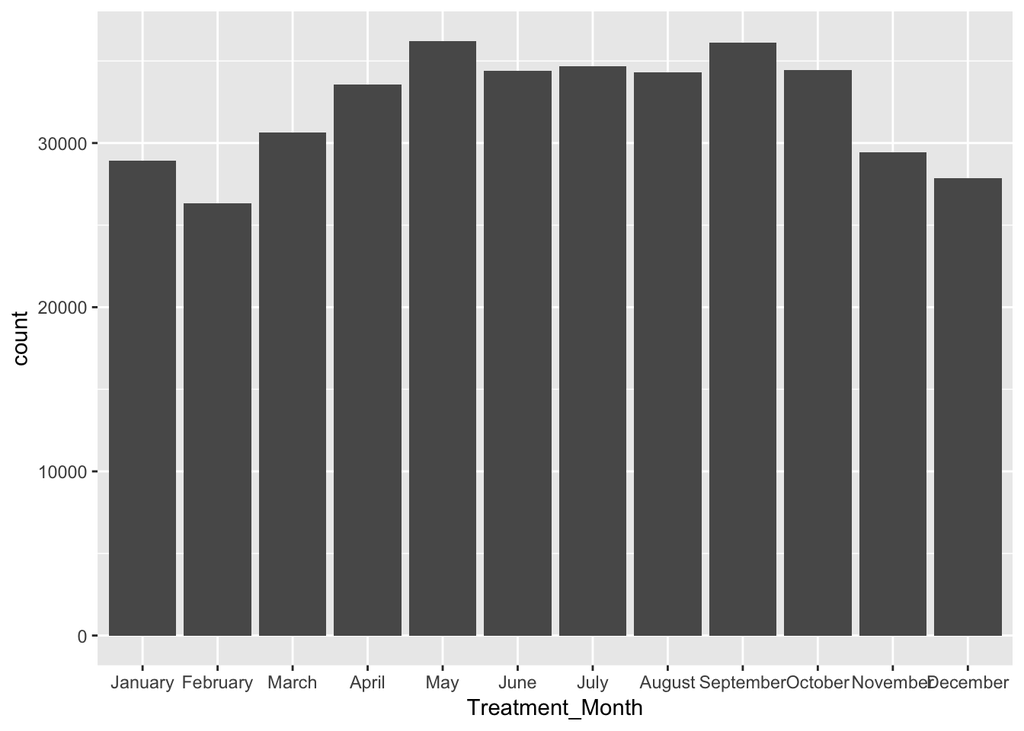

```r
g <- ggplot(neiss, aes(Treatment_Month)) + geom_bar()
g
```

## Applying a Filter before Plotting

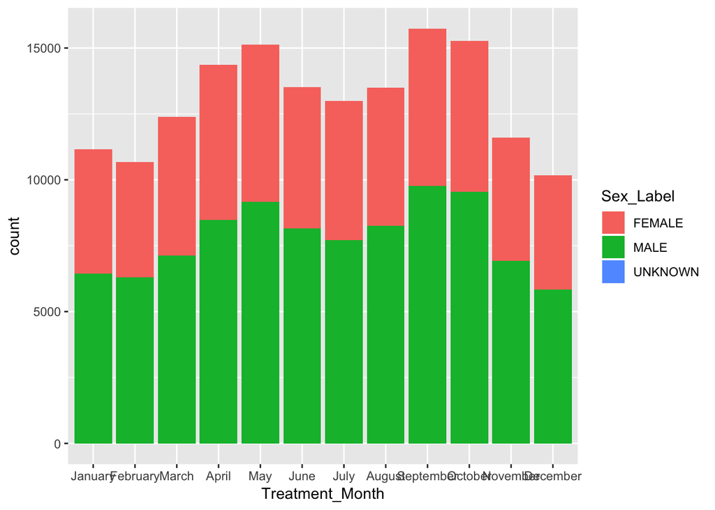

```r
g <- ggplot(filter(neiss, Age < 20), aes(Treatment_Month)) + geom_bar(aes(fill=Sex_Label))
g
```

Here is the same plot with facets.

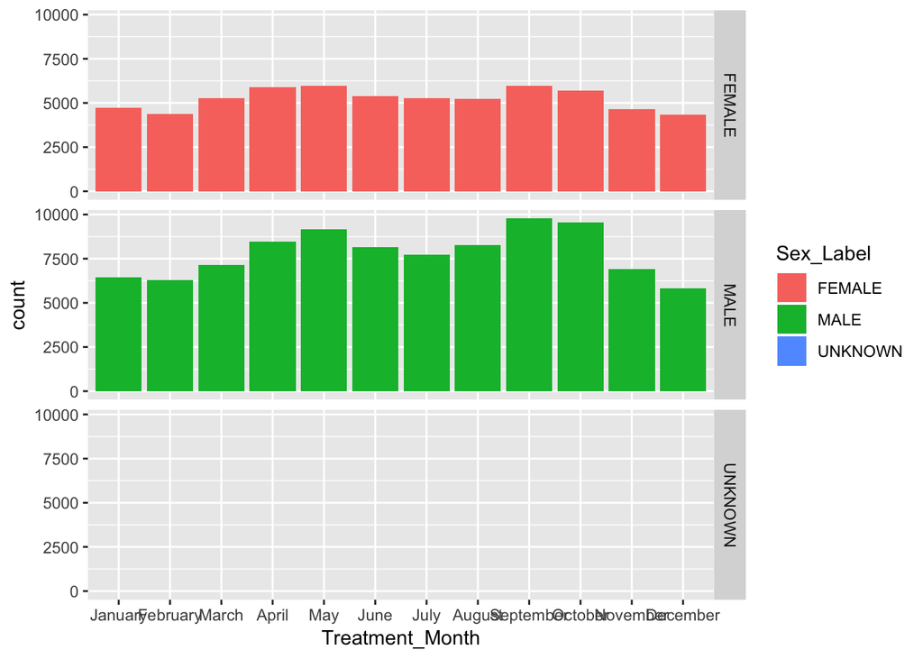

```r
g <- ggplot(filter(neiss, Age < 20), aes(Treatment_Month)) + geom_bar(aes(fill=Sex_Label)) + facet_grid(rows=vars(Sex_Label))
g
```

## In-Class Group Exercise

1. Go to the NEISS website: [https://www.cpsc.gov/Research–Statistics/NEISS-Injury-Data](https://www.cpsc.gov/Research--Statistics/NEISS-Injury-Data)
2. Find the code book: https://www.cpsc.gov/s3fs-public/2017NEISSCodingManualCPSConlyNontrauma.pdf
3. Look up some product codes that you find interesting (e.g. 1313 - Fireworks, 5040 - Bicycles)
4. Create a ggplot that shows the distribution of injuries caused by those products by month
5. Create a ggplot that shows the distribution of injuries caused by those products by weekday
6. Stratify those distributions by sex

### Plot showing the distribution of injuries caused by Fireworks and Bicycles by Month and Sex

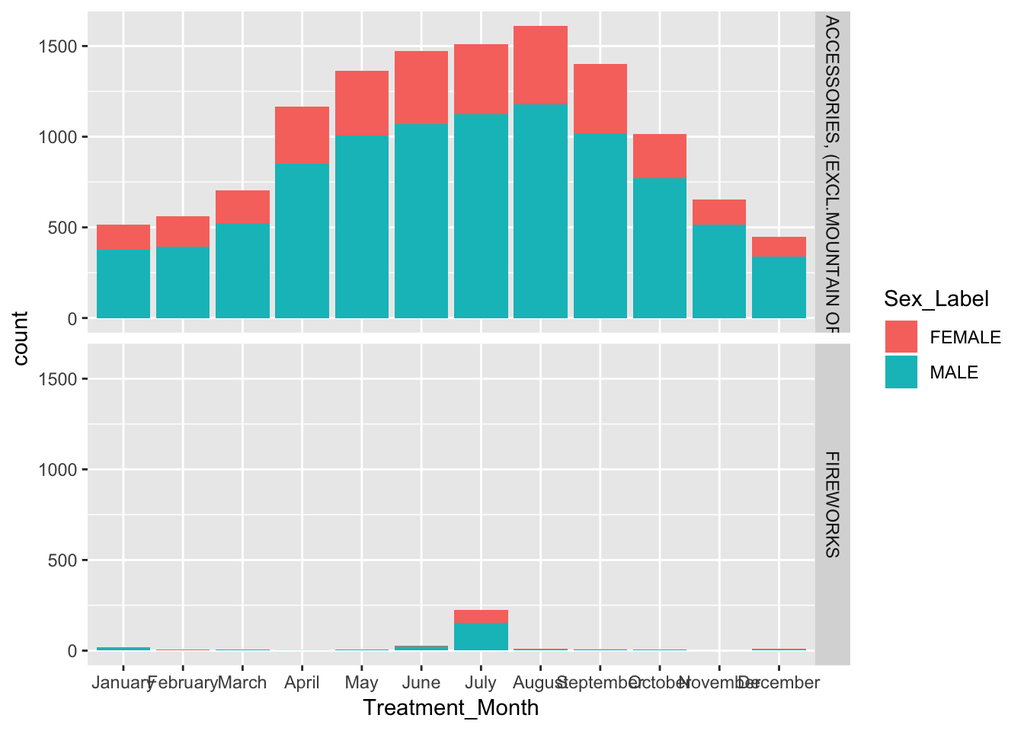

```r
g <- ggplot(filter(neiss, Product_1==1313 | Product_1==5040), aes(Treatment_Month)) + geom_bar(aes(fill=Sex_Label)) + facet_grid(rows=vars(Product_1_Label))
g
```

### Plot showing the distribution of injuries caused by Fireworks and Bicycles by Weekday and Sex

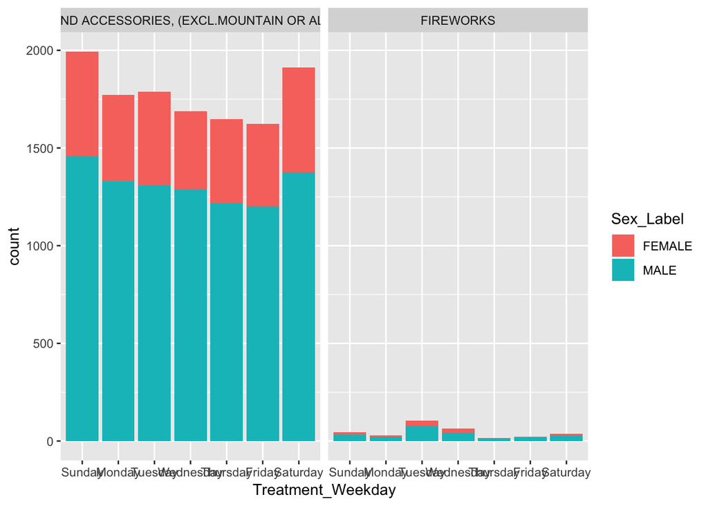

```r
g <- ggplot(filter(neiss, Product_1==1313 | Product_1==5040), aes(Treatment_Weekday)) + geom_bar(aes(fill=Sex_Label)) + facet_grid(cols= vars(Product_1_Label))
g
```

We can also rotate the plot by 90 degrees using `coord_flip`. Adding `x=forcats::fct_rev(Treatment_Weekday)` to the aesthetic of the bar geometry will reverse the order (otherwise the weekdays are listed in reverse chronological order).

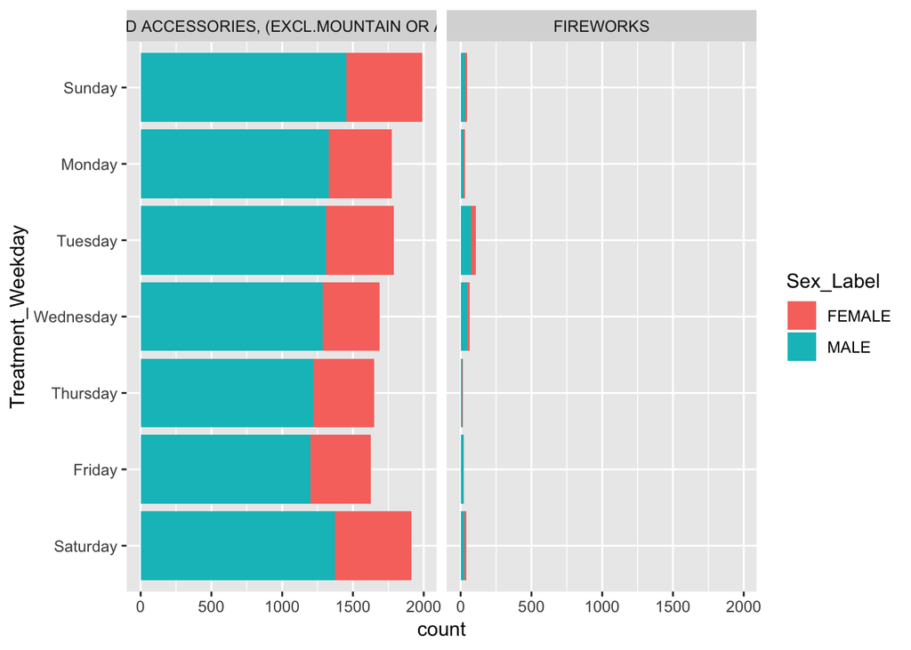

```r
g <- ggplot(filter(neiss, Product_1==1313 | Product_1==5040), aes(Treatment_Weekday)) + geom_bar(aes(fill=Sex_Label, x=forcats::fct_rev(Treatment_Weekday))) + facet_grid(cols= vars(Product_1_Label)) + coord_flip()
g
```

## A couple more `ggplot` examples

## A Simple Data Table

Here is a very simple data table that was used to create the barcharts in *[Streit & Gehlenborg (Nature Methods, 2014)](https://www.nature.com/nmeth/journal/v11/n2/full/nmeth.2807.html)* (PDF).

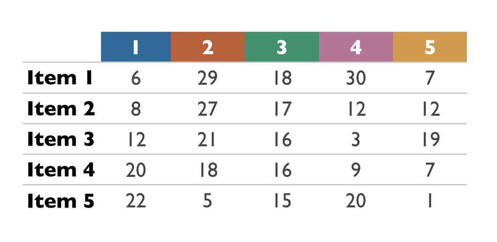

Let’s create a tibble containing this data.

```r
items <- tribble(
~item, ~category1, ~category2, ~category3, ~category4, ~category5,
"item1",    6,  29, 18, 30, 7,
"item2",    8,  27, 17, 12, 12,
"item3",    12, 21, 16, 3,  19,
"item4",    20, 18, 16, 9,  7,
"item5",    22, 5,  15, 20, 1
)
items
```

```
## # A tibble: 5 x 6
##   item  category1 category2 category3 category4 category5
##   <chr>     <dbl>     <dbl>     <dbl>     <dbl>     <dbl>
## 1 item1         6        29        18        30         7
## 2 item2         8        27        17        12        12
## 3 item3        12        21        16         3        19
## 4 item4        20        18        16         9         7
## 5 item5        22         5        15        20         1
```

And now we are ready to plot! Let’s plot the data for `category1` across all items.

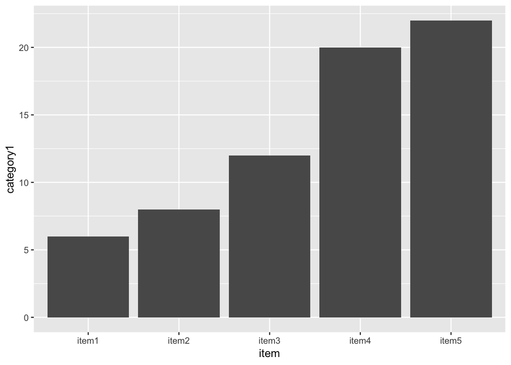

```r
ggplot(data = items) + geom_bar(mapping = aes(x=item, y=category1), stat="identity")
```

What happened? First of all, **our tibble is not tidy!** How do we make it tidy?

```r
items <- items %>% gather(`category1`,`category2`,`category3`,`category4`,`category5`,key="category",value="value")
items
```

```
## # A tibble: 25 x 3
##    item  category  value
##    <chr> <chr>     <dbl>
##  1 item1 category1     6
##  2 item2 category1     8
##  3 item3 category1    12
##  4 item4 category1    20
##  5 item5 category1    22
##  6 item1 category2    29
##  7 item2 category2    27
##  8 item3 category2    21
##  9 item4 category2    18
## 10 item5 category2     5
## # ... with 15 more rows
```

Now we have a tidy tibble that we can use to create a lot of fancy visualizations. But let’s try to reproduce our previous plot first.

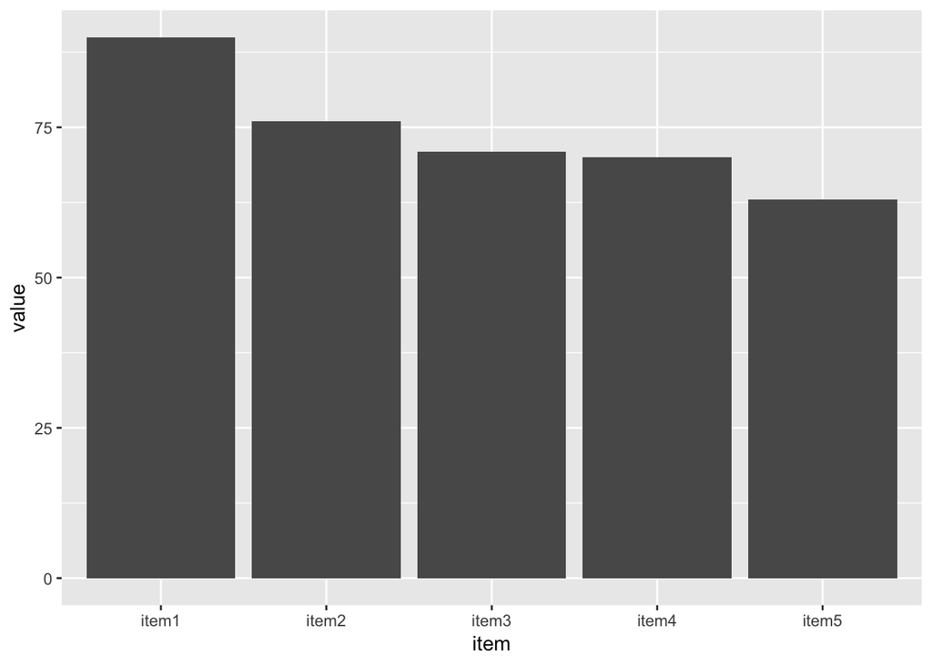

```r
gg <- ggplot(data = items) + geom_bar(mapping = aes(x=item, y=value), stat="identity")
gg
```

This looks different! Maybe this is not surprising, because we didn’t specify that we want to plot `category1`. But what did we get instead? Let’s use an additional aesthetic to include information about the categories. We will use the `fill` aesthetic, which maps a color to each value of a variable. Here we are using the `category` variable.

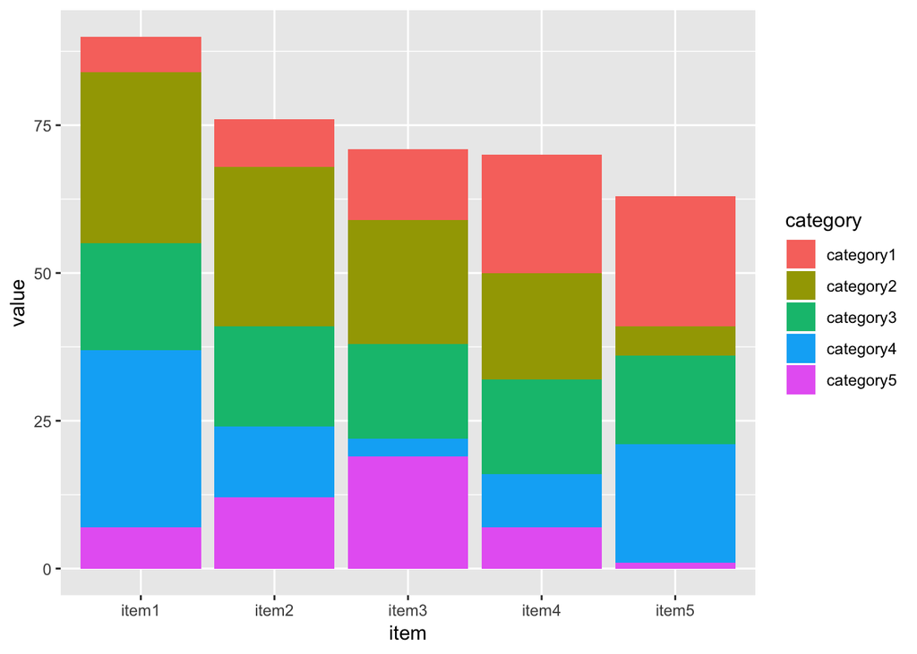

```r
gg <- ggplot(data=items) + geom_bar(mapping=aes(x=item, y=value, fill=category), stat="identity")
gg
```

We created a stacked bar chart. When we compare the order of the categories in the stacks, we find that they are the reverse of the categories in the figure in the Nature Methods column. We will fix this using a factor operation on the `category` variable.

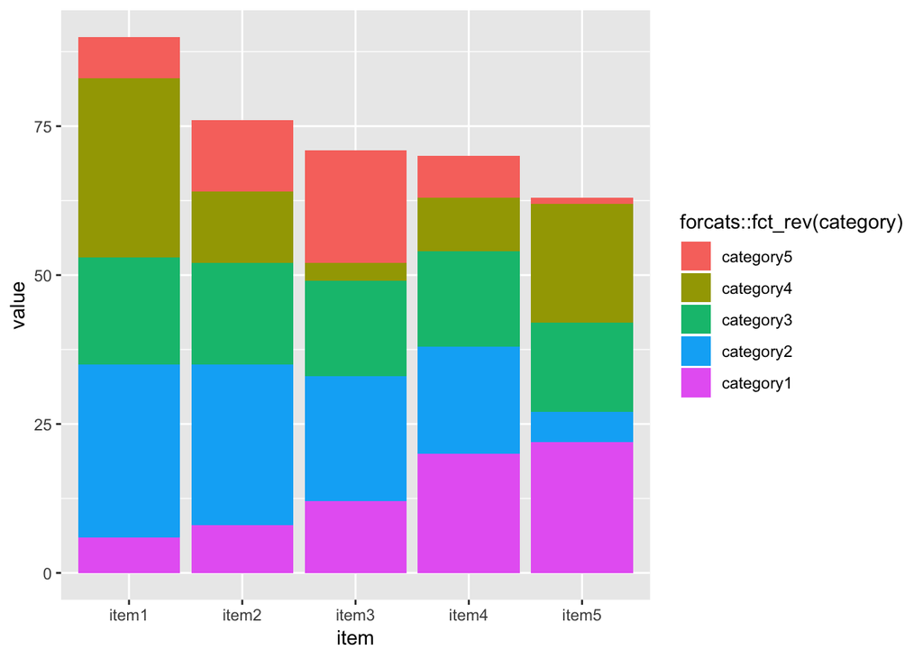

```r
gg <- ggplot(data = items) + geom_bar(mapping = aes(x=item, y=value, fill=forcats::fct_rev(category)), stat="identity")
gg
```

This fixes the order of the categories in the stack but the title of the legend is messed up. `ggplot` allows you to fix the label but we won’t cover this now.

The next step is to rotate the plot by 90 degrees. We simply add that rotation to the existing plot using the `coord_flip` operation.

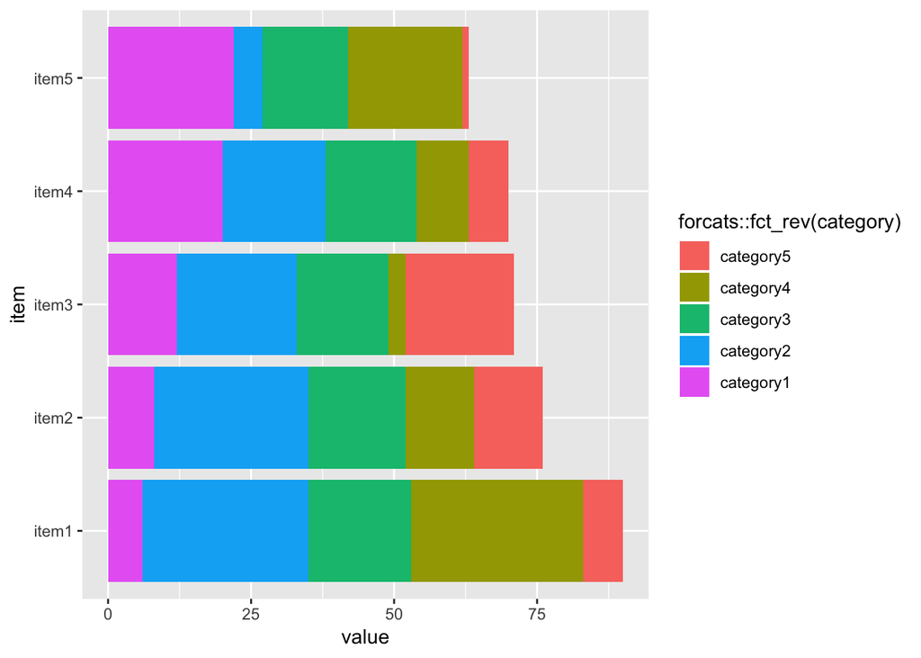

```r
gg <- gg + coord_flip()
gg
```

## Filters

Sometimes we don’t want to plot all the data in our data set. The `tidyverse` offers the handy `filter` function (in the `dplyr` package). We will remove all data but data associated with `category1`.

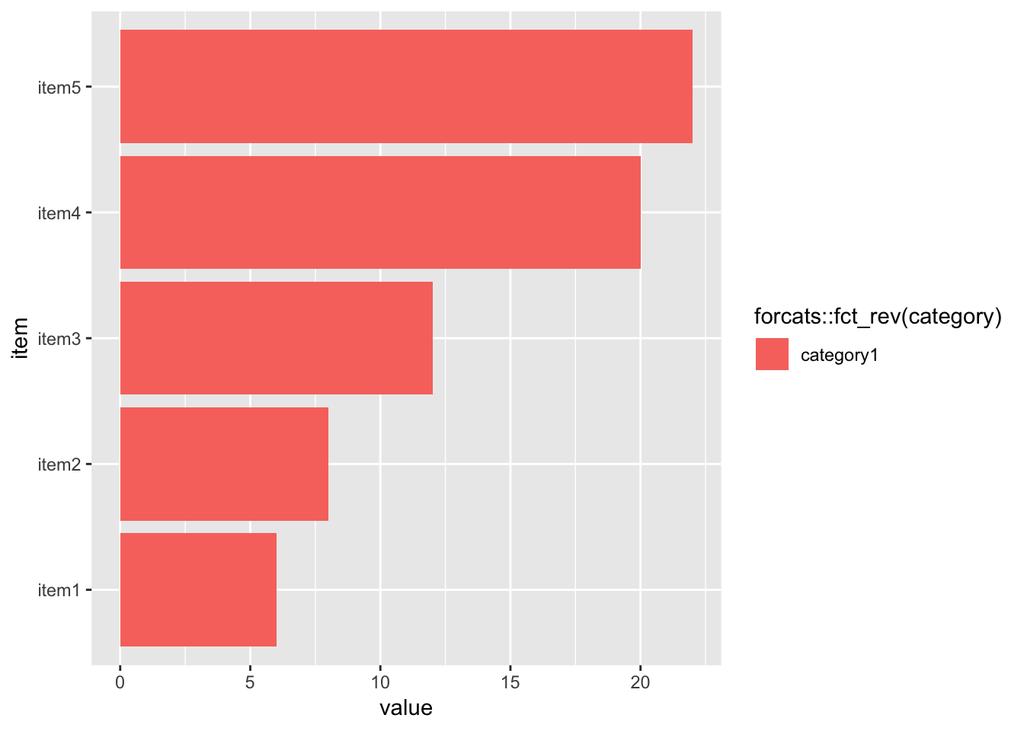

```r
gg <- ggplot(data=filter(items,category=="category1")) + geom_bar(mapping=aes(x=item, y=value, fill=forcats::fct_rev(category)), stat="identity") + coord_flip()
gg
```

What if we want to view data for both `category1` and `category2`?

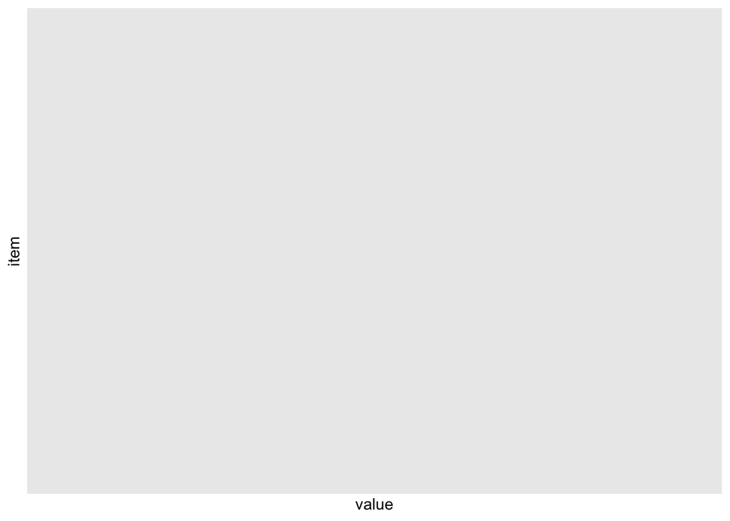

```r
gg <- ggplot(data=filter(items,category=="category1" & category=="category2" )) + geom_bar(mapping=aes(x=item, y=value, fill=forcats::fct_rev(category)), stat="identity") + coord_flip()
gg
```

So why does that not work? `filter` operates on the rows of the `items` tibble and since there is no row that contains **both** `category1` **and** `category2`, the result of the `filter` operation is empty. The correct approach to get data for `category1` and `category2` is to use a logical OR (“|”) operator.

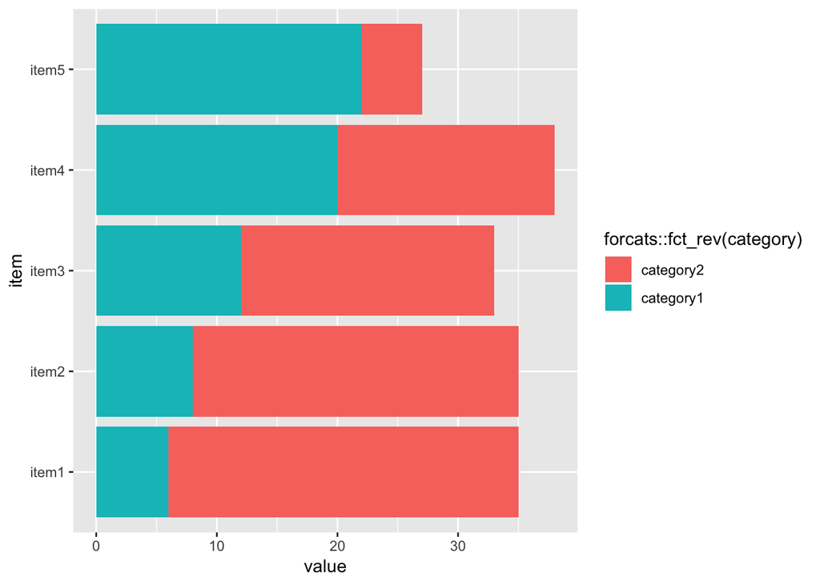

```r
gg <- ggplot(data=filter(items, category=="category1" | category=="category2" )) + geom_bar(mapping=aes(x=item, y=value, fill=forcats::fct_rev(category)), stat="identity") + coord_flip()
gg
```

We can also filter for items at the same time.

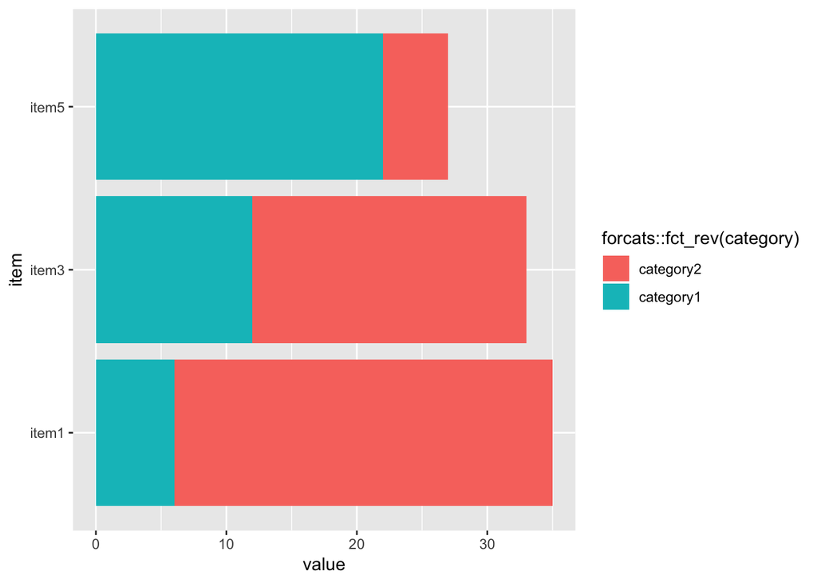

```r
gg <- ggplot(data=filter(items, (item=="item1" | item=="item3" | item=="item5") & (category=="category1" | category=="category2") )) + geom_bar(mapping=aes(x=item, y=value, fill=forcats::fct_rev(category)), stat="identity") + coord_flip()
gg
```

## Creating a Layered Bar Chart

To create the layered bar chart, we need to split the items into one barchart per category. To achieve this, we use the `category` variable to facet the data.

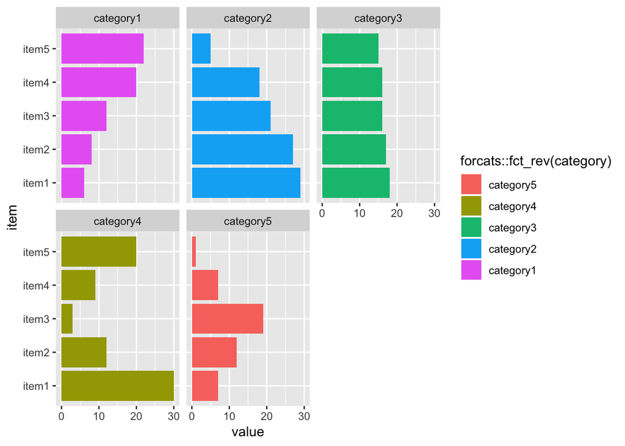

```r
gg <- ggplot(data=items) + geom_bar(mapping=aes(x=item, y=value, fill=forcats::fct_rev(category)), stat="identity") + coord_flip()
gg <- gg + facet_wrap(~category)
gg
```

By default, the faceted plots will be arranged to use the available space. However, the number of rows and columns can be set explicitly as well.

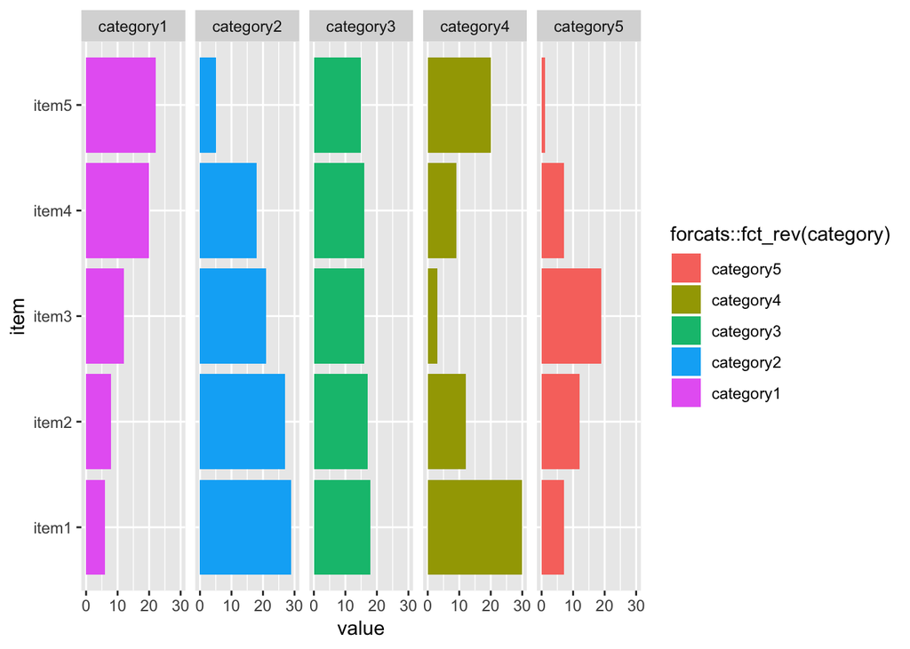

```r
gg <- ggplot(data=items) + geom_bar(mapping=aes(x=item, y=value, fill=forcats::fct_rev(category)), stat="identity") + coord_flip()
gg <- gg + facet_wrap(~category, ncol=5, nrow=1)
gg
```

This looks a bit ugly with the default plot width and aspect ratio. We can fix this by providing explict plot dimensions or an aspect ratio. **Note**: This is an R Markdown feature. How would you do this outside of R Markdown?

[figure not shown]

```r
lbc <- ggplot(data=items) + geom_bar(mapping=aes(x=item, y=value, fill=forcats::fct_rev(category)), stat="identity") + coord_flip()
lbc <- lbc + facet_wrap(~category, ncol=5, nrow=1)
lbc
```

## Creating a Grouped Bar Chart

To go from a layered bar chart to a grouped bar chart is very simple with our tibble and ggplot. We need to change only two things:

1. The `x` aesthetic. Instead of grouping bars by items, we now want to group them by categories.
2. The variable used to facet. Instead of faceting by category, we now want to facet by item.

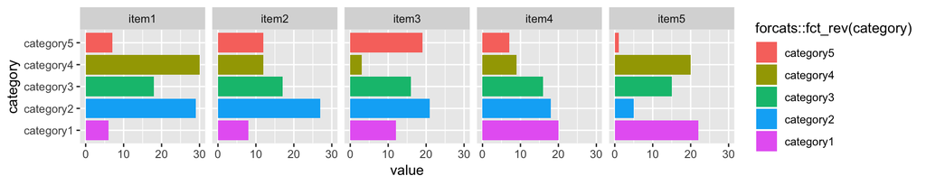

```r
gbc <- ggplot(data=items) + geom_bar(mapping=aes(x=category, y=value, fill=forcats::fct_rev(category)), stat="identity") + coord_flip()
gbc <- gbc + facet_wrap(~item, ncol=5, nrow=1)
gbc
```

To create the same arrangement as in the Nature Methods colum, we remove `coord_flip`.

[figure not shown]

```r
gbc <- ggplot(data=items) + geom_bar(mapping=aes(x=category, y=value, fill=forcats::fct_rev(category)), stat="identity")
gbc <- gbc + facet_wrap(~item, ncol=5, nrow=1)
gbc
```

## Modifying the Coordinate System

We can switch from Cartesian coordinates to polar coordinates very easily.

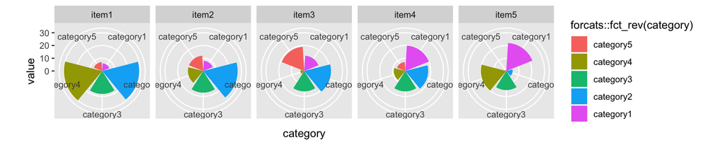

```r
gg <- ggplot(data=items) + geom_bar(mapping=aes(x=category, y=value, fill=forcats::fct_rev(category)), stat="identity") + coord_polar("x")
gg <- gg + facet_wrap(~item, ncol=5, nrow=1)
gg
```

We can apply them to either the `x` or the `y` axis.

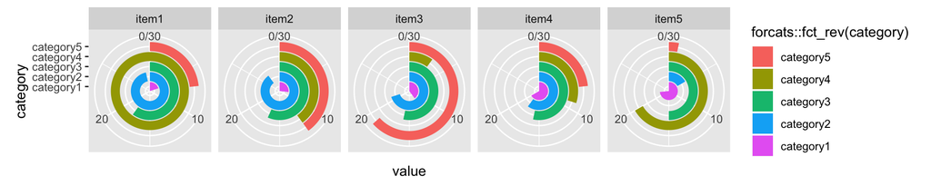

```r
gg <- ggplot(data=items) + geom_bar(mapping=aes(x=category, y=value, fill=forcats::fct_rev(category)), stat="identity") + coord_polar("y")
gg <- gg + facet_wrap(~item, ncol=5, nrow=1)
gg
```

This looks fancy but is pretty useless from a visualization point of view. Why? **Note**: You can use this transformation to create pie charts. Because they are not a good visualization approach, I will let you figure this out yourself.

## Colors and Themes

We can easily replace the colors used in these plots. Colors are provided as `scale`. **Note**: There is difference between `color` and `fill`! What is it?

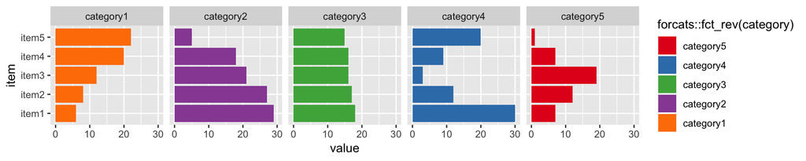

```r
lbc <- ggplot(data=items) + geom_bar(mapping=aes(x=item, y=value, fill=forcats::fct_rev(category)), stat="identity") + coord_flip()
lbc <- lbc + scale_fill_brewer(palette = "Set1") + facet_wrap(~category, ncol=5, nrow=1)
lbc
```

This color palette is from the Color Brewer website: http://colorbrewer2.org. Let’s talk a bit about color!

We can also use custom color palettes (from the`viridis` package).

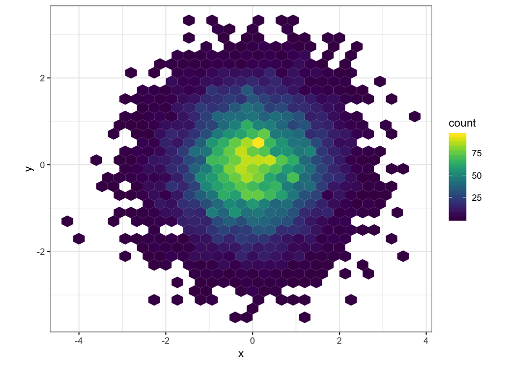

```r
ggplot(data.frame(x = rnorm(10000), y = rnorm(10000)), aes(x = x, y = y)) +
  geom_hex() + coord_fixed() +
  scale_fill_viridis() + theme_bw()
```

We can also use custom color palettes:

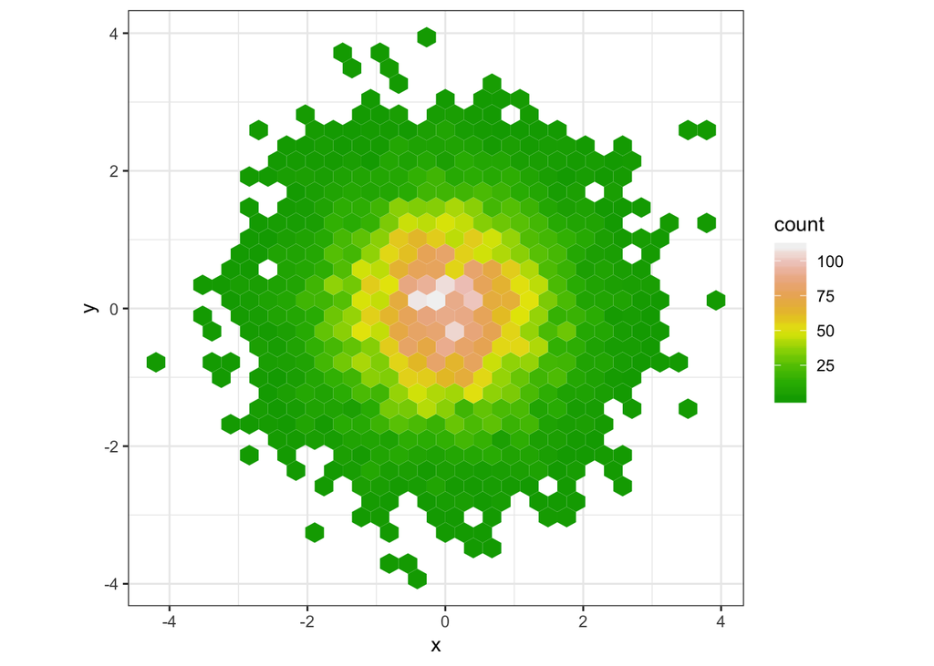

```r
ggplot(data.frame(x = rnorm(10000), y = rnorm(10000)), aes(x = x, y = y)) +
  geom_hex() + coord_fixed() + theme_bw() +
  scale_fill_gradientn(colours = terrain.colors(10))
```

While scales are used to control the colors used for data, the remainder of the plots is controlled by themes.

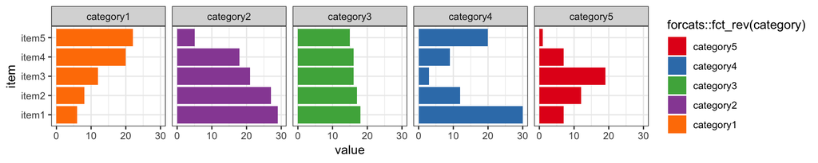

```r
lbc <- ggplot(data=items) + geom_bar(mapping=aes(x=item, y=value, fill=forcats::fct_rev(category)), stat="identity") + coord_flip()
lbc <- lbc + theme_bw() + scale_fill_brewer(palette = "Set1") + facet_wrap(~category, ncol=5, nrow=1)
lbc
```

There are a lot of default themes and they can be customized as well.

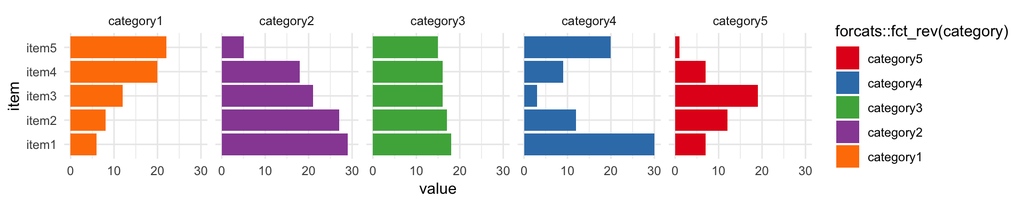

```r
lbc <- ggplot(data=items) + geom_bar(mapping=aes(x=item, y=value, fill=forcats::fct_rev(category)), stat="identity") + coord_flip()
lbc <- lbc + theme_minimal() + scale_fill_brewer(palette = "Set1") + facet_wrap(~category, ncol=5, nrow=1)
lbc
```